# Wealth effect on PISA Scores

## by Simón Muñoz

## Do wealthy students do better at PISA?

The Programme for International Student Assessment (PISA) is a worldwide study by the Organisation for Economic Co-operation and Development (OECD) in member and non-member nations intended to evaluate educational systems by measuring 15-year-old school pupils' scholastic performance on mathematics, science, and reading.

Along the following slides, we are going to observe the influence (if any) that different wealth levels in students have in their PISA Scores.

## Our data indicates that wealthy students obtain better Pisa scores

First of all, the analysis of our data confirms that wealthy students get better scores in the three disciplines PISA measures, reading, maths and sciences.

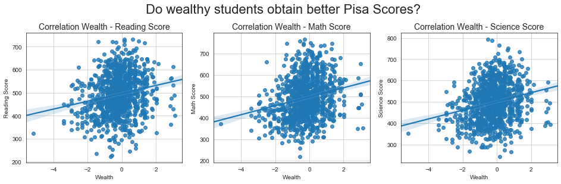

```python
# Let´s plot the correlation between wealth and the pisa scores
plt.figure(figsize = [16,4])
plt.suptitle('Do wealthy students obtain better Pisa Scores?', fontsize=22, y='1.05')

ax1 = plt.subplot(1, 3, 1) # 1 row, 3 cols, subplot 1
sb.regplot(data = df_sample, x = 'wealth', y = 'reading_score');
decorate_subplot(ax1, "Correlation Wealth - Reading Score", "Wealth", "Reading Score")

ax2 = plt.subplot(1, 3, 2)
sb.regplot(data = df_sample, x = 'wealth', y = 'math_score');
decorate_subplot(ax2, "Correlation Wealth - Math Score", "Wealth", "Math Score")

ax3 = plt.subplot(1, 3, 3)
sb.regplot(data = df_sample, x = 'wealth', y = 'science_score');
decorate_subplot(ax3, "Correlation Wealth - Science Score", "Wealth", "Science Score")
```

## But wealthy students don't do more homework than non-wealthy ones

One of the insights extracted from the data is that study time out of class like homework, has a positive impact on the PISA scores of the students. Could wealthy students have more time available for this task?

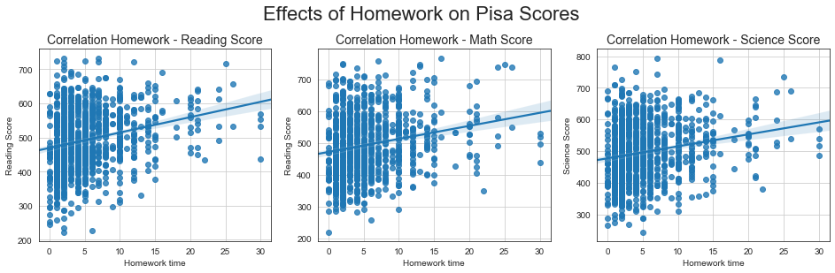

```python
# Let´s plot the correlation between the scores and the homework time
plt.figure(figsize = [16,4])
plt.suptitle('Effects of Homework on Pisa Scores', fontsize=22, y='1.05')

ax1 = plt.subplot(1, 3, 1)
sb.regplot(data = df_sample, x = 'out-of-school_study_time_-_homework', y = 'reading_score');
decorate_subplot(ax1, "Correlation Homework - Reading Score", "Homework time", "Reading Score")

ax2 = plt.subplot(1, 3, 2)
sb.regplot(data = df_sample, x = 'out-of-school_study_time_-_homework', y = 'math_score');
decorate_subplot(ax2, "Correlation Homework - Math Score", "Homework time", "Reading Score")

ax3 = plt.subplot(1, 3, 3)
sb.regplot(data = df_sample, x = 'out-of-school_study_time_-_homework', y = 'science_score');
decorate_subplot(ax3, "Correlation Homework - Science Score", "Homework time", "Science Score")
```

However, this doesn´t seem to be the cause of the wealthy students obtaining better scores, as the data indicates that wealthy students do not dedicate more time to study than non wealty ones.

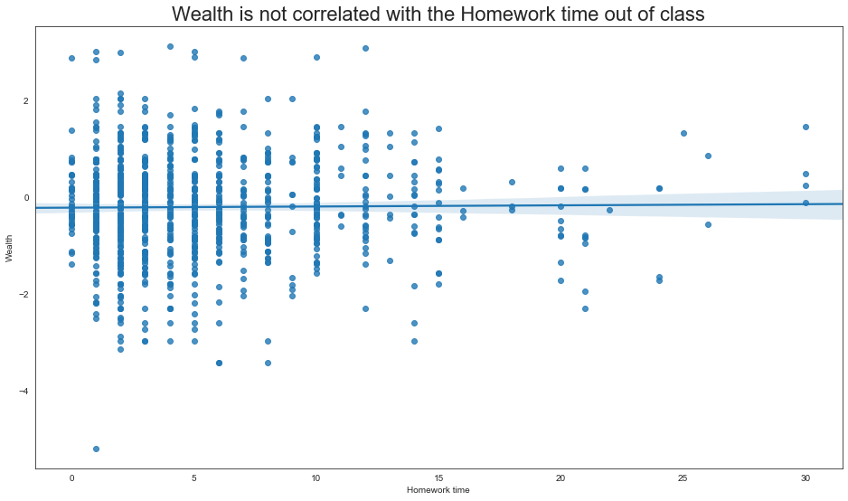

```python
# Let´s plot the correlation between wealth and study time out of school

# Plot the birth month variable
fig = plt.subplots(figsize=(16,9))
ax = sb.regplot(data = df_sample, x = 'out-of-school_study_time_-_homework', y = 'wealth');
decorate("Wealth is not correlated with the Homework time out of class", "Homework time", "Wealth")
```

## Wealthy students tend to have more books at home than non-wealthy ones

Observing the data, we can attest that one of the factors that influence positively the different PISA Scores is the number of books per households.

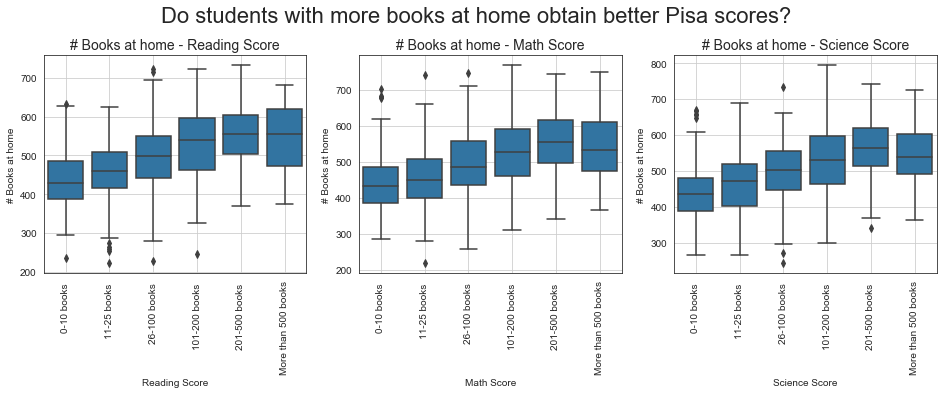

```python
# Boxplots relationing books at home - pisa scores
books_cat_order = ["0-10 books ", "11-25 books ", "26-100 books ", "101-200 books ", "201-500 books ", "More than 500 books"]
plt.figure(figsize = [16,4])
plt.suptitle('Do students with more books at home obtain better Pisa scores?', fontsize=22, y='1.05')

ax1 = plt.subplot(1, 3, 1)
sb.boxplot(data = df_sample, x = 'how_many_books_at_home', y = 'reading_score',
    color = base_color, order=books_cat_order);
decorate_subplot(ax1, "# Books at home - Reading Score", "Reading Score", "# Books at home");
plt.xticks(rotation=90);

ax2 = plt.subplot(1, 3, 2)
sb.boxplot(data = df_sample, x = 'how_many_books_at_home', y = 'math_score',
              color = base_color, order=books_cat_order);
decorate_subplot(ax2, "# Books at home - Math Score", "Math Score", "# Books at home");
plt.xticks(rotation=90);

ax3 = plt.subplot(1, 3, 3)
sb.boxplot(data = df_sample, x = 'how_many_books_at_home', y = 'science_score',
              color = base_color, order=books_cat_order);
decorate_subplot(ax3, "# Books at home - Science Score", "Science Score", "# Books at home");
plt.xticks(rotation=90);
```

And in fact, **wealthy students tend to have more books at home** than non-wealthy ones, so this could be one of the causes of the advantage for these students.

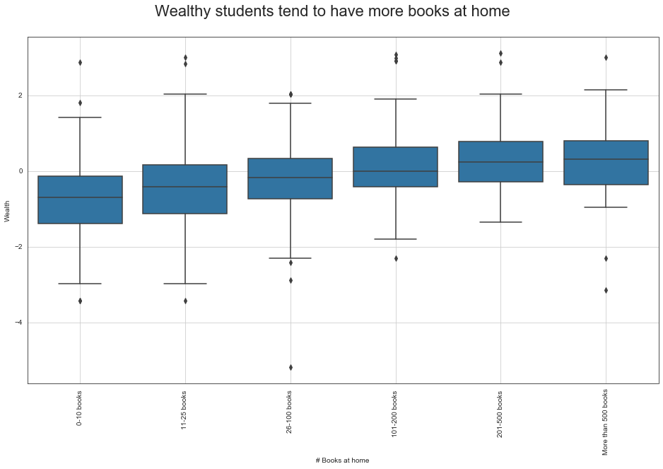

```python
# Boxplots relationing books at home - pisa scores
books_cat_order = ["0-10 books ", "11-25 books ", "26-100 books ", "101-200 books ", "201-500 books ", "More than 500 books"]
plt.figure(figsize = [16,9])
plt.suptitle('Wealthy students tend to have more books at home', fontsize=22, y=.95)

ax = sb.boxplot(data = df_sample, x = 'how_many_books_at_home', y = 'wealth',
    color = base_color, order=books_cat_order);
decorate_subplot(ax, "", "# Books at home", "Wealth");
plt.xticks(rotation=90);
```

## Wealthy students also have more chances to own a computer

Another factor influencing positively PISA scores has been the possession of a computer.

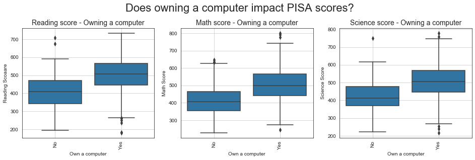

```python
# Boxplots relationing owning a computer and PISA scores
plt.figure(figsize = [16,4])
plt.suptitle('Does owning a computer impact PISA scores?', fontsize=22, y='1.05')

ax1 = plt.subplot(1, 3, 1)
sb.boxplot(data = df_sample, x = 'possessions_-_computer', y = 'reading_score', color = base_color)
decorate_subplot(ax1, "Reading score - Owning a computer", "Own a computer", "Reading Scoaare")
plt.xticks(rotation=90);

ax2 = plt.subplot(1, 3, 2)
sb.boxplot(data = df_sample, x = 'possessions_-_computer', y = 'math_score', color = base_color)
decorate_subplot(ax2, "Math score - Owning a computer", "Own a computer", "Math Score")
plt.xticks(rotation=90);

ax3 = plt.subplot(1, 3, 3)
sb.boxplot(data = df_sample, x = 'possessions_-_computer', y = 'science_score', color = base_color)
decorate_subplot(ax3, "Science score - Owning a computer", "Own a computer", "Science Score")
plt.xticks(rotation=90);
```

And this is another of the advantages that wealthy students have over non-wealthy ones.

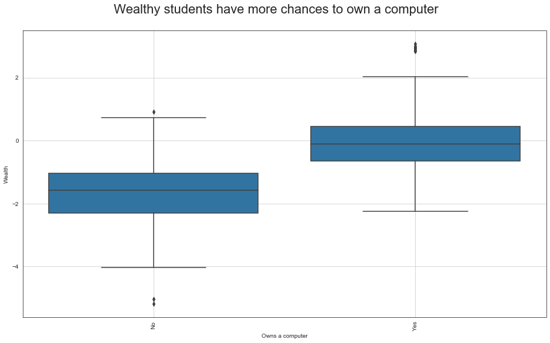

```python
# Boxplots relationing books at home - pisa scores
plt.figure(figsize = [16,9])
plt.suptitle('Wealthy students have more chances to own a computer', fontsize=22, y=.95)

ax = sb.boxplot(data = df_sample, x = 'possessions_-_computer', y = 'wealth',
    color = base_color);
decorate_subplot(ax, "", "Owns a computer", "Wealth");
plt.xticks(rotation=90);
```

## Having access to more resources seem to improve your PISA scores

We´ve seen that having books at home and owning a computer increases your PISA scores. What we haven´t seen until now is that students having access to both resources are the ones who get the better scores.

[figure not shown]

```python
# Relationship between 2 categorical and 1 numerical variable
fig = plt.figure(figsize = [16,4])
plt.suptitle('Students with both a high number of books at home and a computer obtain the better scores', fontsize=22, y='1.05')

plt.subplot(1, 3, 1)
ax1 = sb.pointplot(data = df_clean, x = 'how_many_books_at_home', y = 'reading_score', hue = 'possessions_-_computer',
           palette = 'Blues', linestyles = '', dodge = 0.4, order=books_cat_order);
decorate_subplot(ax1, "Reading Score", "# Books at home", "Reading Score");
plt.xticks(rotation=90);

plt.subplot(1, 3, 2)
ax2 = sb.pointplot(data = df_clean, x = 'how_many_books_at_home', y = 'math_score', hue = 'possessions_-_computer',
           palette = 'Blues', linestyles = '', dodge = 0.4, order=books_cat_order);
decorate_subplot(ax2, "Math Score", "# Books at home", "Math Score");
plt.xticks(rotation=90);

plt.subplot(1, 3, 3)
ax3 = sb.pointplot(data = df_clean, x = 'how_many_books_at_home', y = 'science_score', hue = 'possessions_-_computer',
           palette = 'Blues', linestyles = '', dodge = 0.4, order=books_cat_order);
decorate_subplot(ax3, "Science Score", "# Books at home", "Science Score");
plt.xticks(rotation=90);
```

## Conclusions

- Wealth level of students has a clear positive effect on their PISA scores
- Wealthy students do not study out of class more than non wealthy ones
- Students with more books at home tend to obtain better scores.
- Also, owning a computer seems to be positively correlated with getting better scores.
- Wealthy students have greater chances of having more books at home and owning a computer.
- Students with a high number of books at home and who own a computer are ones getting the higher scores.

Given our analysis, we can conclude that apparently, wealth levels are an important factor in the academic performance of students.

```python
g = sb.FacetGrid(data = df_clean, col = 'gender', size = 4)
g.map(sb.boxplot, 'at_school_-_desktop_computer', 'math_score')
```

[output not shown]